# Chapter 10 Summary

## Setup

```r
setwd("/Users/anjali/Documents/university/Econ_5305/code_directory/Chapter10")
rm(list = ls())
```

```r
library(openxlsx)
library(readxl)
library(ggplot2)
library(dynlm)
library(forecast)
library(urca)
```

## Question 5

```r
data <- read_excel("ch10_q5_data.xls")

# read the complete time series
MORTGAGE<-ts(data$MORTGAGE, frequency =4, start = c(1951,10))

# split the data. Don't consider the last 12 periods
last_index <- length(MORTGAGE)
MORTGAGE_split<-ts(data$MORTGAGE[1:(last_index - 12)], frequency =4, start = c(1951,10))
```

```r
summary(data)
```

```
 observation_date                 MORTGAGE
 Min.   :1951-10-01 00:00:00   Min.   :   92435
 1st Qu.:1968-09-08 00:00:00   1st Qu.:  422668
 Median :1985-08-16 00:00:00   Median : 2410103
 Mean   :1985-08-16 03:00:00   Mean   : 4816977
 3rd Qu.:2002-07-24 00:00:00   3rd Qu.: 8159305
 Max.   :2019-07-01 00:00:00   Max.   :15841071
```

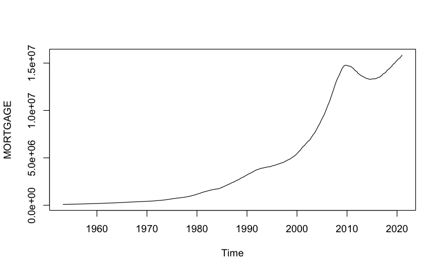

```r
plot(MORTGAGE)
```

**Key Findings:** The plot shows that there is an upward trend. There is break in the trend around the early 2010s (2012 - 2014). The plot also clearly does not look linear. It looks polynomial from the plot

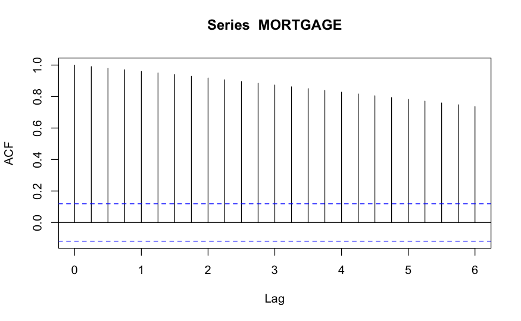

```r
acf(MORTGAGE)
```

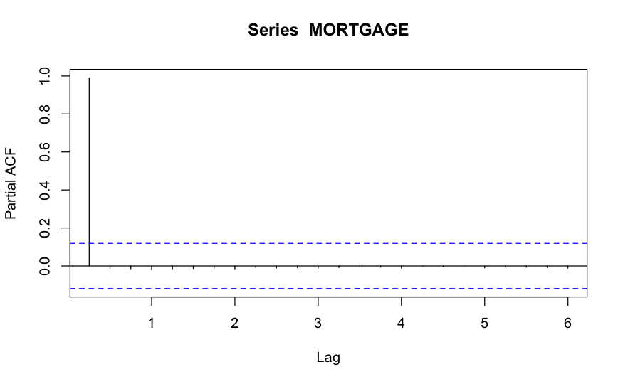

```r
pacf(MORTGAGE)
```

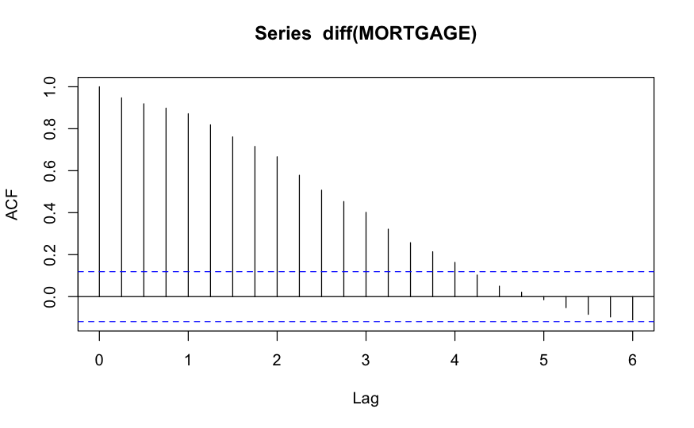

```r
acf(diff(MORTGAGE))
```

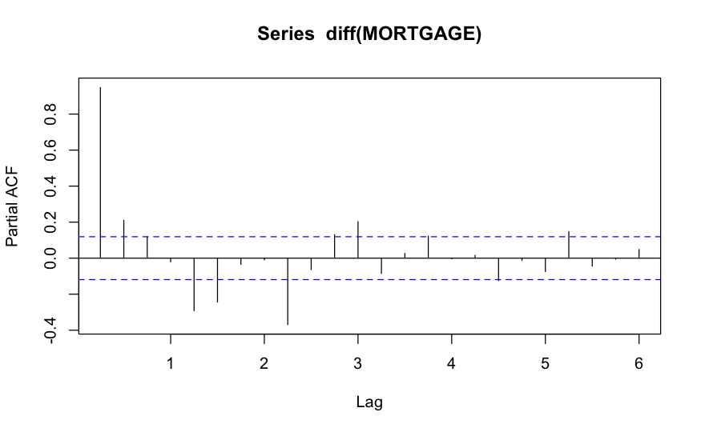

```r
pacf(diff(MORTGAGE))
```

```r
ur.df(MORTGAGE,type="trend",lags=0)
```

```
###############################################################
# Augmented Dickey-Fuller Test Unit Root / Cointegration Test #
###############################################################

The value of the test statistic is: -1.3014 61.3735 30.5779
```

```r
ur.df(diff(MORTGAGE),type="trend",lags=0)
```

```
###############################################################
# Augmented Dickey-Fuller Test Unit Root / Cointegration Test #
###############################################################

The value of the test statistic is: -2.8197 2.7222 4.0098
```

#### This also looks like it has a unit root. Why are we not doing the unit root testing here?

#### Model1: Polynomial model of degree 4

```r
n = length(MORTGAGE)
trend1 = ts(c(1:n), frequency = 4, start = c(1951,1))
model_poly4 <-lm(MORTGAGE ~ poly(trend1, 4, raw=TRUE))
summary(model_poly4)
```

```
Call:
lm(formula = MORTGAGE ~ poly(trend1, 4, raw = TRUE))

Residuals:
     Min       1Q   Median       3Q      Max
-1572947  -413601     1507   398179  2914956

Coefficients:
                               Estimate Std. Error t value Pr(>|t|)
(Intercept)                  -8.882e+05  2.706e+05  -3.282  0.00117 **
poly(trend1, 4, raw = TRUE)1  9.171e+04  1.368e+04   6.702 1.22e-10 ***
poly(trend1, 4, raw = TRUE)2 -1.790e+03  2.033e+02  -8.805  < 2e-16 ***
poly(trend1, 4, raw = TRUE)3  1.252e+01  1.118e+00  11.199  < 2e-16 ***
poly(trend1, 4, raw = TRUE)4 -2.342e-02  2.031e-03 -11.527  < 2e-16 ***
---
Signif. codes:  0 ‘***’ 0.001 ‘**’ 0.01 ‘*’ 0.05 ‘.’ 0.1 ‘ ’ 1

Residual standard error: 873100 on 267 degrees of freedom
Multiple R-squared:  0.9735,    Adjusted R-squared:  0.9731
F-statistic:  2450 on 4 and 267 DF,  p-value: < 2.2e-16
```

```r
AIC(model_poly4)
```

```
[1] 8220.664
```

```r
BIC(model_poly4)
```

```
[1] 8242.299
```

```r
plot.ts(MORTGAGE, ylab="", lty=2)
fit <- ts(fitted(model_poly4), frequency = 4, start=c(1951,1))
res <- ts(resid(model_poly4), frequency = 4, start=c(1951,1))
lines(fit, col="red", lty=2)
```

```r
par(new=TRUE)
plot.ts(res, axes=FALSE, ylab="", col="blue")
```

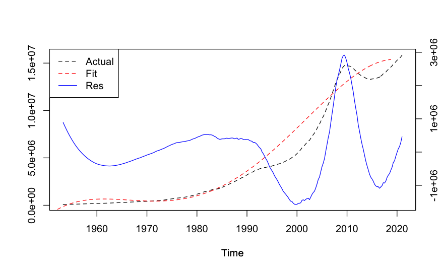

```r
axis(side=4, at = pretty(range(res)))
legend("topleft", legend=c("Actual", "Fit", "Res"), lty=c(2,2,1), col=c("black", "red", "blue"))
```

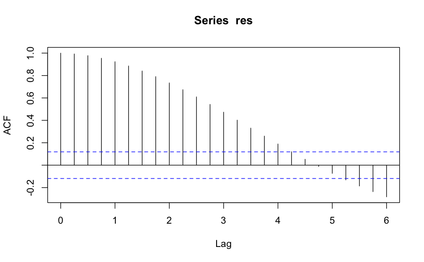

```r
acf(res)
```

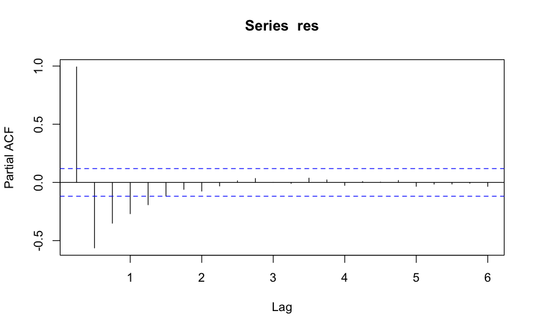

```r
pacf(res)
```

##### Model 2: using log transformation (my model)

```r
logMORTGAGE<- log(MORTGAGE)
n = length(logMORTGAGE)
trend1 = ts(c(1:n), frequency = 4, start = c(1951,1))
model_log <-lm(logMORTGAGE ~ poly(trend1, 2, raw=TRUE))
summary(model_log)
```

```
Call:
lm(formula = logMORTGAGE ~ poly(trend1, 2, raw = TRUE))

Residuals:
     Min       1Q   Median       3Q      Max
-0.22908 -0.09289  0.00484  0.09212  0.31890

Coefficients:
                               Estimate Std. Error t value Pr(>|t|)
(Intercept)                   1.127e+01  2.351e-02  479.47   <2e-16 ***
poly(trend1, 2, raw = TRUE)1  2.878e-02  3.977e-04   72.37   <2e-16 ***
poly(trend1, 2, raw = TRUE)2 -3.103e-05  1.411e-06  -22.00   <2e-16 ***
---
Signif. codes:  0 ‘***’ 0.001 ‘**’ 0.01 ‘*’ 0.05 ‘.’ 0.1 ‘ ’ 1

Residual standard error: 0.1283 on 269 degrees of freedom
Multiple R-squared:  0.9937,    Adjusted R-squared:  0.9937
F-statistic: 2.125e+04 on 2 and 269 DF,  p-value: < 2.2e-16
```

```r
AIC(model_log)
```

```
[1] -340.0845
```

```r
BIC(model_log)
```

```
[1] -325.6613
```

```r
plot.ts(logMORTGAGE, ylab="", lty=2)
fit <- ts(fitted(model_log), frequency = 4, start=c(1951,1))
res <- ts(resid(model_log), frequency = 4, start=c(1951,1))
lines(fit, col="red", lty=2)
```

```r
par(new=TRUE)
plot.ts(res, axes=FALSE, ylab="", col="blue")
```

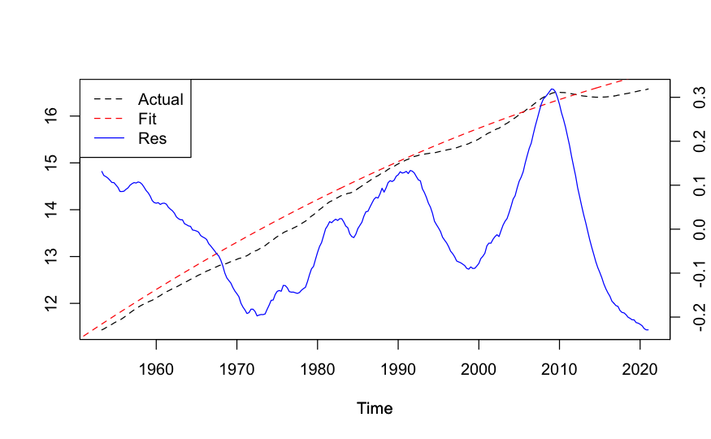

```r
axis(side=4, at = pretty(range(res)))
legend("topleft", legend=c("Actual", "Fit", "Res"), lty=c(2,2,1), col=c("black", "red", "blue"))
```

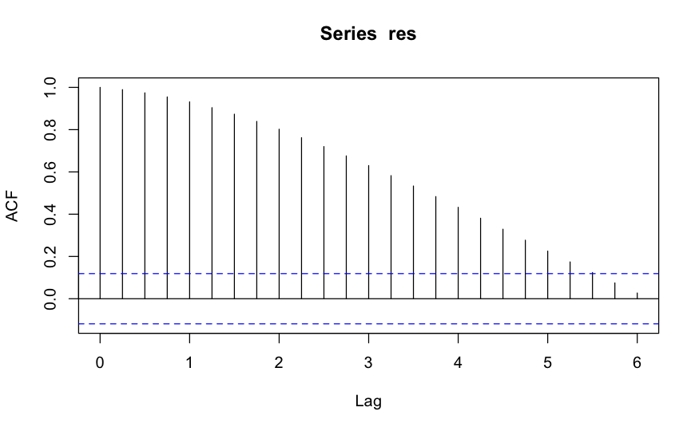

```r
acf(res)
```

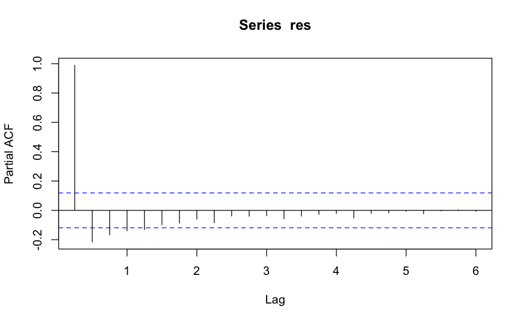

```r
pacf(res)
```

#### Model 3: Jibok’s Model with 5 lags included.

```r
n = length(MORTGAGE)
trend1 = ts(c(1:n), frequency = 4, start = c(1951,1))
model_poly_ar <- dynlm(MORTGAGE ~ trend1+I(trend1^2)+I(trend1^3)+I(trend1^4)+lag(MORTGAGE,-1)+lag(MORTGAGE,-2)+lag(MORTGAGE,-3)+lag(MORTGAGE,-4)+lag(MORTGAGE,-5)) #AR(2) + polynomial(4) trend
summary(model_poly_ar)
```

```
Time series regression with "ts" data:
Start = 1954(3), End = 2018(4)

Call:
dynlm(formula = MORTGAGE ~ trend1 + I(trend1^2) + I(trend1^3) +
    I(trend1^4) + lag(MORTGAGE, -1) + lag(MORTGAGE, -2) + lag(MORTGAGE,
    -3) + lag(MORTGAGE, -4) + lag(MORTGAGE, -5))

Residuals:
    Min      1Q  Median      3Q     Max
-111687   -4680    -718    7794   98224

Coefficients:
                    Estimate Std. Error t value Pr(>|t|)
(Intercept)       -2.248e+04  1.603e+04  -1.402  0.16209
trend1             1.412e+03  7.163e+02   1.971  0.04980 *
I(trend1^2)       -2.282e+01  9.854e+00  -2.315  0.02140 *
I(trend1^3)        1.432e-01  5.275e-02   2.716  0.00708 **
I(trend1^4)       -2.393e-04  9.149e-05  -2.616  0.00945 **
lag(MORTGAGE, -1)  1.600e+00  6.307e-02  25.366  < 2e-16 ***
lag(MORTGAGE, -2) -5.373e-01  1.198e-01  -4.483 1.12e-05 ***
lag(MORTGAGE, -3)  1.053e-01  1.246e-01   0.845  0.39916
lag(MORTGAGE, -4) -6.262e-02  1.211e-01  -0.517  0.60568
lag(MORTGAGE, -5) -1.205e-01  6.490e-02  -1.856  0.06458 .
---
Signif. codes:  0 ‘***’ 0.001 ‘**’ 0.01 ‘*’ 0.05 ‘.’ 0.1 ‘ ’ 1

Residual standard error: 25890 on 248 degrees of freedom
Multiple R-squared:      1, Adjusted R-squared:      1
F-statistic: 1.087e+06 on 9 and 248 DF,  p-value: < 2.2e-16
```

```r
AIC(model_poly_ar)
```

```
[1] 5987.35
```

```r
BIC(model_poly_ar)
```

```
[1] 6026.432
```

```r
plot.ts(MORTGAGE, ylab="", lty=2)
fit <- ts(fitted(model_poly_ar), frequency = 4, start=c(1951,1))
res <- ts(resid(model_poly_ar), frequency = 4, start=c(1951,1))
lines(fit, col="red", lty=2)
par(new=TRUE)
plot.ts(res, axes=FALSE, ylab="", col="blue")
axis(side=4, at = pretty(range(res)))
legend("topleft", legend=c("Actual", "Fit", "Res"), lty=c(2,2,1), col=c("black", "red", "blue"))
acf(res)
pacf(res)
```

[output not shown]

```r
MORTGAGE_part<-ts(data$`MORTGAGE`[1:260], frequency =4, start = c(1951,10))
original<-ts(data$`MORTGAGE`[1:272], frequency =4, start = c(1951,10))
trend1 = ts(c(1:260), frequency = 4, start = c(1951,10))
model <- dynlm(MORTGAGE_part ~ trend1+I(trend1^2)+I(trend1^3)+I(trend1^4)+lag(MORTGAGE_part,-1)+stats::lag(MORTGAGE_part,-2)+stats::lag(MORTGAGE_part,-3)+stats::lag(MORTGAGE_part,-4)+stats::lag(MORTGAGE_part,-5)) #AR(2) + polynomial(4) trend
fcast=union(MORTGAGE_part, c(261:272))
fpoly = ts(c(261:272), frequency = 4, start = c(2016,10))
print(fpoly)
```

```
     Qtr1 Qtr2 Qtr3 Qtr4
2018       261  262  263
2019  264  265  266  267
2020  268  269  270  271
2021  272
```

```r
#print(MORTGAGE_part)
for(i in 1:12){
  fcast[260+i]<-coef(model)[1] +coef(model)[2]*(fpoly[i]) +coef(model)[3]*((fpoly[i])^2)
              +coef(model)[4]*((fpoly[i])^3)+coef(model)[5]*((fpoly[i])^4)
              +coef(model)[6]*fcast[259+i]+coef(model)[7]*fcast[258+i]+coef(model)[8]*fcast[257+i]
              +coef(model)[9]*fcast[256+i]+coef(model)[10]*fcast[255+i]
}

fcast = ts(fcast, frequency = 4, start = c(1951,10))
ts.plot(fcast) #plot of the forecast
lines(original, col=6)
```

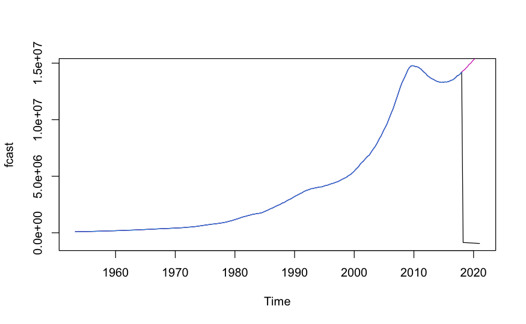

```r
lines(MORTGAGE_part, col=4)
```

## Don’t know why my forecast looks totally different ?

## Question 10

#### 10.1 Read data on total hours worked in United States(Index)

```r
data_2 <- read_excel("ch10_q10_data.xls")
View(data_2)
```

#### 10.2 Preliminary EDA

```r
# read the time series total hours worked index
US<-ts(data_2$hours_worked_index,frequency=12,start=c(2006,3), end =c(2023,3))
cat("Hours worked in United States(Index)")
```

```
Hours worked in United States(Index)
```

```r
summary(US)
```

```
   Min. 1st Qu.  Median    Mean 3rd Qu.    Max.
   91.0    97.7   101.3   102.4   107.9   115.1
```

```r
cat("Standard deviation: ", sd(US))
```

```
Standard deviation:  6.523515
```

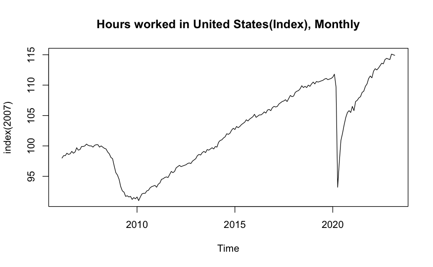

```r
plot.ts(US, main="Hours worked in United States(Index), Monthly",ylab ="index(2007)")
```

**Notes** There is an upward sloping trend that we can see visually. The series is nonstationary.There is break in trend at some points like 2010 and 2020. There appears to be drift as well.

```r
ur.df(US,type="drift",lags=0)
```

```
###############################################################
# Augmented Dickey-Fuller Test Unit Root / Cointegration Test #
###############################################################

The value of the test statistic is: -0.8495 0.7773
```

```r
ur.df(diff(US),type="drift",lags=0)
```

```
###############################################################
# Augmented Dickey-Fuller Test Unit Root / Cointegration Test #
###############################################################

The value of the test statistic is: -14.4962 105.0705
```

**There is a unit root:(integration order = 1)** Since the test-statistic is -0.85 (-0.85 not less than -2.9) we cannot reject the null hypothesis. Therefore there is a unit root. DF testing on the diff(T_US) indicates that there is no unit root therefore there is only 1 unit root of the integration order = 1

```r
library(dynlm) #use dynlm package
dUS<-diff(US)
model <-dynlm(dUS ~ lag(US,-1)) #regression correspondingg to the above ADF test
summary(model) #estimation output
```

```
Time series regression with "ts" data:
Start = 2006(4), End = 2023(3)

Call:
dynlm(formula = dUS ~ lag(US, -1))

Residuals:
     Min       1Q   Median       3Q      Max
-16.4951  -0.2053   0.0820   0.2847   3.9081

Coefficients:
            Estimate Std. Error t value Pr(>|t|)
(Intercept)  1.30379    1.44007   0.905    0.366
lag(US, -1) -0.01193    0.01404  -0.850    0.397

Residual standard error: 1.297 on 202 degrees of freedom
Multiple R-squared:  0.00356,   Adjusted R-squared:  -0.001373
F-statistic: 0.7217 on 1 and 202 DF,  p-value: 0.3966
```

```r
AIC(model)
```

```
[1] 688.8812
```

```r
## [1] 171.2994
BIC(model)
```

```
[1] 698.8356
```

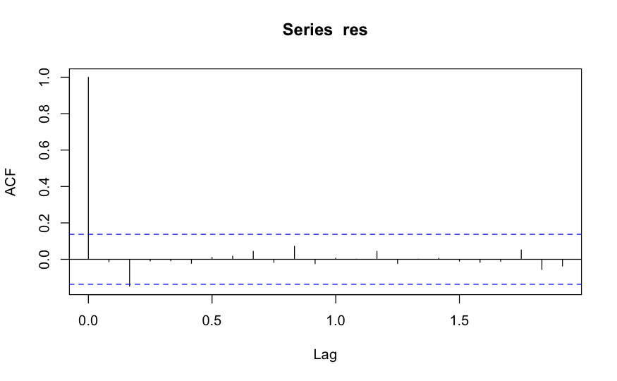

```r
## [1] 175.6966
res <-  residuals(model) #generate residuals
acf(res)
```

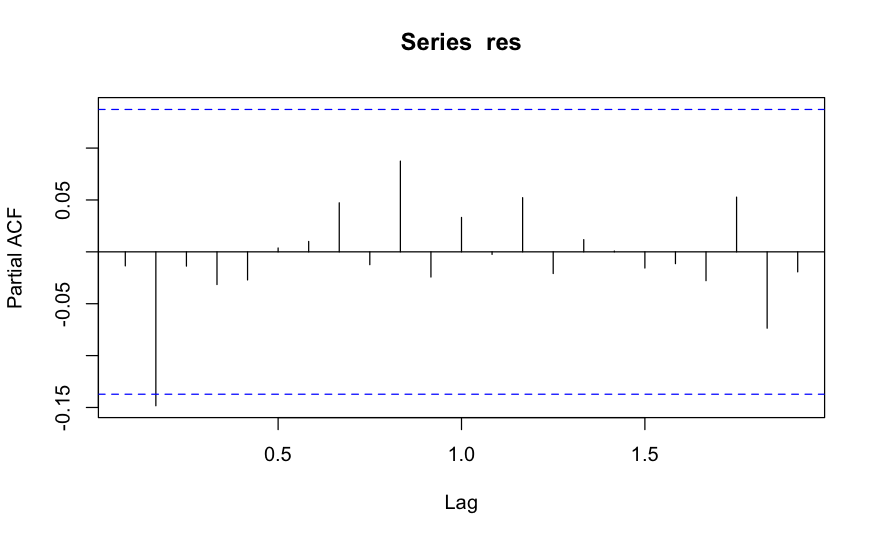

```r
pacf(res)
```

```r
Box.test(residuals(model), lag = 20, type="Ljung")
```

```
    Box-Ljung test

data:  residuals(model)
X-squared = 7.2335, df = 20, p-value = 0.9958
```

**The residuals are not showing a pattern:** Looking at the ACF and PACF it looks quite close to noise. So we can use this model for forecast. In the class example we also had to construct an AR(1) model as the residuals had a pattern to them.

## Having difficulty in making the forecast

```r
fcast=union(US, c(1,2,3,4)) #fcast will include actual US and 4 forecasts for US
fcastd=union(dUS, c(1,2,3,4)) #fcastd will include actual dUS and 4 forecasts for dUS
length(US)
```

```
[1] 205
```

```r
length(dUS)
```

```
[1] 204
```

```r
start_index_us <-length(fcast)
start_index_dus <-length(fcastd)
start_index_us
```

```
[1] 143
```

```r
start_index_dus
```

```
[1] 42
```

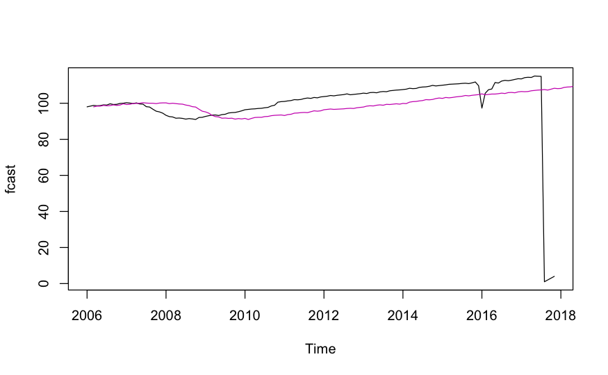

```r
#for(i in 1:4){
#  fcastd[(start_index - 1) + i]=coef(model)[1]*fcastd[(start_index) + i]
#  fcast[start_index + i]=fcast[(start_index - 1) + i]+fcastd[(start_index - 1) +i]
#}
# P288, fig 10.13
fcast = ts(fcast, frequency = 12, start = 2006)
ts.plot(fcast) #plot of the forecast
lines(US, col=6) #simualtaneous plotting of the actual series in magenta color
```

```r
ur.df(US,type="drift",lags=1)
```

```
###############################################################
# Augmented Dickey-Fuller Test Unit Root / Cointegration Test #
###############################################################

The value of the test statistic is: -0.7985 0.7304
```

```r
model <-dynlm(dUS ~ lag(US,-1)+lag(US,-1)) #regression corresponding to the above ADF test
summary(model)
```

```
Time series regression with "ts" data:
Start = 2006(4), End = 2023(3)

Call:
dynlm(formula = dUS ~ lag(US, -1) + lag(US, -1))

Residuals:
     Min       1Q   Median       3Q      Max
-16.4951  -0.2053   0.0820   0.2847   3.9081

Coefficients:
            Estimate Std. Error t value Pr(>|t|)
(Intercept)  1.30379    1.44007   0.905    0.366
lag(US, -1) -0.01193    0.01404  -0.850    0.397

Residual standard error: 1.297 on 202 degrees of freedom
Multiple R-squared:  0.00356,   Adjusted R-squared:  -0.001373
F-statistic: 0.7217 on 1 and 202 DF,  p-value: 0.3966
```

```r
AIC(model)
```

```
[1] 688.8812
```

```r
## [1] 134.9974
BIC(model)
```

```
[1] 698.8356
```

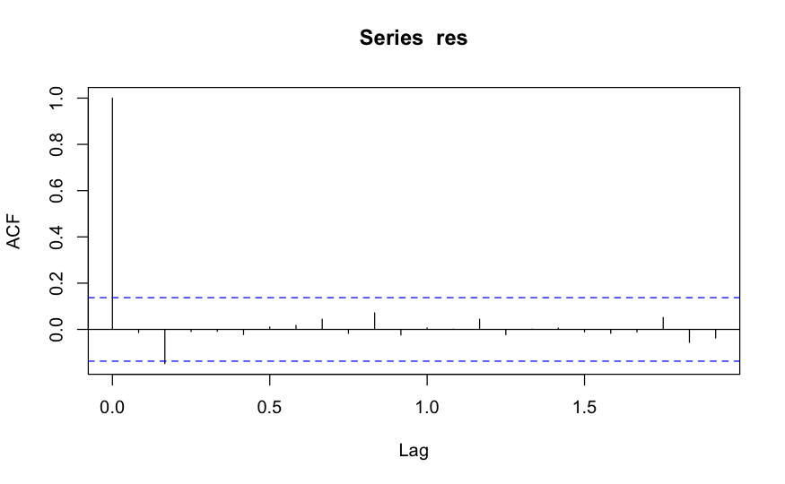

```r
## [1] 140.7334
res<-  residuals(model)
acf(res)
```

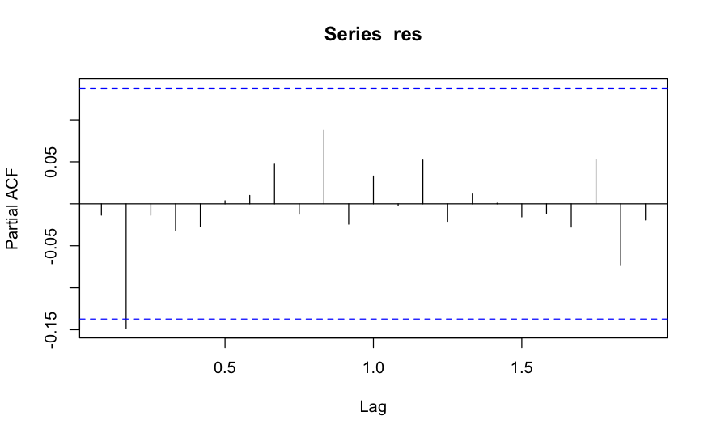

```r
pacf(res)
```

```r
Box.test(residuals(model), lag = 20, type="Ljung")
```

```
    Box-Ljung test

data:  residuals(model)
X-squared = 7.2335, df = 20, p-value = 0.9958
```

```r
# P287 Prepare to forecast table 10.8
model <-dynlm(dUS ~ lag(dUS,-1)+0) #AR(1) w/o constant for differenced series
summary(model)
```

```
Time series regression with "ts" data:
Start = 2006(5), End = 2023(3)

Call:
dynlm(formula = dUS ~ lag(dUS, -1) + 0)

Residuals:
     Min       1Q   Median       3Q      Max
-16.5378  -0.1018   0.1964   0.3973   3.8030

Coefficients:
             Estimate Std. Error t value Pr(>|t|)
lag(dUS, -1) -0.01800    0.07033  -0.256    0.798

Residual standard error: 1.301 on 202 degrees of freedom
Multiple R-squared:  0.0003242, Adjusted R-squared:  -0.004625
F-statistic: 0.06551 on 1 and 202 DF,  p-value: 0.7982
```

```r
AIC(model)
```

```
[1] 685.9268
```

```r
## [1] 135.857
BIC(model)
```

```
[1] 692.5532
```

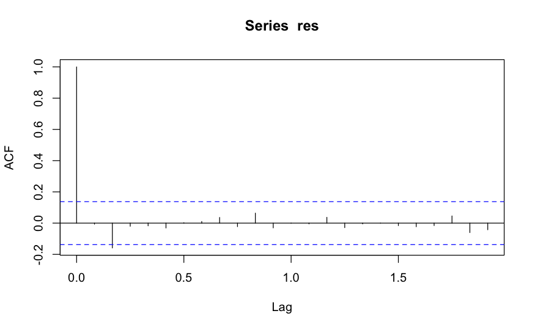

```r
## [1] 138.725
res<-  residuals(model)
acf(res)
```

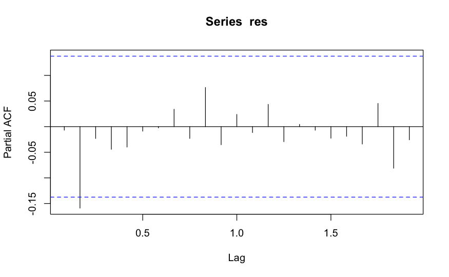

```r
pacf(res)
```

```r
Box.test(residuals(model), lag = 20, type="Ljung")
```

```
    Box-Ljung test

data:  residuals(model)
X-squared = 7.8399, df = 20, p-value = 0.9929
```